# Consumo de alimento en salmones bajo 20% de actividad y su relación con FCRc y SGRc

Pedro Pizarro

01 July 2022

### Base de datos

Los datos a utilizar corresponden a una base de datos con 7 variables: Año de cultivo **(Year_class)**, unidad de cultivo **(Jaula)** ,fecha en que se cosechó la jaula **(Fecha_cosecha)**, el alimento consumido bajo 20% de actividad **(Consumo_bajo_20)**, factor de conversión corregido **(FCRc)** y tasa de crecimiento específica corregida **(SGRc)**.

```r
read_excel("Base_Datos_Cons_FCR_SGR.xlsx")
```

```
## # A tibble: 273 × 7
##    Year_class Fecha_cosecha       Centro    Jaula   `Consumo_ bajo…`  FCRc  SGRc
##         <dbl> <dttm>              <chr>     <chr>              <dbl> <dbl> <dbl>
##  1       2021 2021-08-29 00:00:00 Chivato 1 Chivat…           0.0201 0.892  1.13
##  2       2021 2021-09-02 00:00:00 Chivato 1 Chivat…           0.0156 0.91   1.10
##  3       2021 2021-09-07 00:00:00 Chivato 1 Chivat…           0.0754 0.968  1.05
##  4       2021 2021-09-18 00:00:00 Chivato 1 Chivat…           0.0579 0.966  1.06
##  5       2021 2021-09-20 00:00:00 Chivato 1 Chivat…           0.0375 0.942  1.04
##  6       2021 2021-09-23 00:00:00 Chivato 1 Chivat…           0.0715 0.911  1.07
##  7       2021 2021-09-23 00:00:00 Chivato 1 Chivat…           0.0721 0.985  1.06
##  8       2021 2021-09-29 00:00:00 Chivato 1 Chivat…           0.0775 0.966  1.08
##  9       2021 2021-10-01 00:00:00 Chivato 1 Chivat…           0.0383 0.932  1.05
## 10       2021 2021-10-03 00:00:00 Chivato 1 Chivat…           0.0274 0.936  1.05
## # … with 263 more rows
```

```r
BDatos <-read_excel("Base_Datos_Cons_FCR_SGR.xlsx")
```

```r
dfSummary(BDatos, style = "grid")
```

```
## Data Frame Summary
## BDatos
## Dimensions: 273 x 7
## Duplicates: 0
##
## +----+-------------------+--------------------------+---------------------+---------------------+----------+---------+
## | No | Variable          | Stats / Values           | Freqs (% of Valid)  | Graph               | Valid    | Missing |
## +====+===================+==========================+=====================+=====================+==========+=========+
## | 1  | Year_class        | Mean (sd) : 2020.9 (0.6) | 2020 :  51 (18.7%)  | III                 | 273      | 0       |
## |    | [numeric]         | min < med < max:         | 2021 : 187 (68.5%)  | IIIIIIIIIIIII       | (100.0%) | (0.0%)  |
## |    |                   | 2020 < 2021 < 2022       | 2022 :  35 (12.8%)  | II                  |          |         |
## |    |                   | IQR (CV) : 0 (0)         |                     |                     |          |         |
## +----+-------------------+--------------------------+---------------------+---------------------+----------+---------+
## | 2  | Fecha_cosecha     | min : 2020-07-16         | 204 distinct values |     : :             | 273      | 0       |
## |    | [POSIXct, POSIXt] | med : 2021-05-13         |                     |     : :             | (100.0%) | (0.0%)  |
## |    |                   | max : 2022-10-11         |                     |   : : :   .         |          |         |
## |    |                   | range : 2y 2m 25d        |                     | : : : : : :         |          |         |
## |    |                   |                          |                     | : : : : : :         |          |         |
## +----+-------------------+--------------------------+---------------------+---------------------+----------+---------+
## | 3  | Centro            | 1. Orestes               | 24 ( 8.8%)          | I                   | 273      | 0       |
## |    | [character]       | 2. Elena Weste           | 22 ( 8.1%)          | I                   | (100.0%) | (0.0%)  |
## |    |                   | 3. Punta Cola            | 22 ( 8.1%)          | I                   |          |         |
## |    |                   | 4. Punta Rouse           | 22 ( 8.1%)          | I                   |          |         |
## |    |                   | 5. Williams 1            | 22 ( 8.1%)          | I                   |          |         |
## |    |                   | 6. Elena Norte           | 21 ( 7.7%)          | I                   |          |         |
## |    |                   | 7. Chivato 1             | 18 ( 6.6%)          | I                   |          |         |
## |    |                   | 8. Dring 1               | 18 ( 6.6%)          | I                   |          |         |
## |    |                   | 9. Isla Level 2          | 18 ( 6.6%)          | I                   |          |         |
## |    |                   | 10. Tangbac              | 18 ( 6.6%)          | I                   |          |         |
## |    |                   | [ 6 others ]             | 68 (24.9%)          | IIII                |          |         |
## +----+-------------------+--------------------------+---------------------+---------------------+----------+---------+
## | 4  | Jaula             | 1. Chivato 1101          |   1 ( 0.4%)         |                     | 273      | 0       |
## |    | [character]       | 2. Chivato 1102          |   1 ( 0.4%)         |                     | (100.0%) | (0.0%)  |
## |    |                   | 3. Chivato 1103          |   1 ( 0.4%)         |                     |          |         |
## |    |                   | 4. Chivato 1104          |   1 ( 0.4%)         |                     |          |         |
## |    |                   | 5. Chivato 1105          |   1 ( 0.4%)         |                     |          |         |
## |    |                   | 6. Chivato 1106          |   1 ( 0.4%)         |                     |          |         |
## |    |                   | 7. Chivato 1107          |   1 ( 0.4%)         |                     |          |         |
## |    |                   | 8. Chivato 1108          |   1 ( 0.4%)         |                     |          |         |
## |    |                   | 9. Chivato 1109          |   1 ( 0.4%)         |                     |          |         |
```

[output cut: 21 more lines]

```r
summary(BDatos)
```

```
##    Year_class   Fecha_cosecha                    Centro
##  Min.   :2020   Min.   :2020-07-16 00:00:00   Length:273
##  1st Qu.:2021   1st Qu.:2021-01-27 00:00:00   Class :character
##  Median :2021   Median :2021-05-13 00:00:00   Mode  :character
##  Mean   :2021   Mean   :2021-05-23 21:00:39
##  3rd Qu.:2021   3rd Qu.:2021-09-01 00:00:00
##  Max.   :2022   Max.   :2022-10-11 00:00:00
##     Jaula           Consumo_ bajo_ 20      FCRc            SGRc
##  Length:273         Min.   :0.00000   Min.   :0.862   Min.   :0.713
##  Class :character   1st Qu.:0.02613   1st Qu.:0.968   1st Qu.:0.978
##  Mode  :character   Median :0.07054   Median :1.010   Median :1.007
##                     Mean   :0.08499   Mean   :1.012   Mean   :1.007
##                     3rd Qu.:0.12117   3rd Qu.:1.047   3rd Qu.:1.050
##                     Max.   :0.40443   Max.   :1.223   Max.   :1.189
```

En el resumen, las características de los datos de las variables recomiendan la transformación a factor de algunas de ellas.

```r
BDatos$Year_class <- as.factor(BDatos$Year_class)
BDatos$`Fecha_cosecha` <- as.factor(BDatos$`Fecha_cosecha`)
BDatos$Jaula <-as.factor(BDatos$Jaula)
BDatos$Centro <- as.factor (BDatos$Centro)
summary(BDatos)
```

```
##  Year_class    Fecha_cosecha         Centro             Jaula
##  2020: 51   2021-04-21: 13   Orestes    : 24   Chivato 1101:  1
##  2021:187   2020-08-27:  6   Elena Weste: 22   Chivato 1102:  1
##  2022: 35   2020-08-13:  3   Punta Cola : 22   Chivato 1103:  1
##             2021-01-10:  3   Punta Rouse: 22   Chivato 1104:  1
##             2021-02-11:  3   Williams 1 : 22   Chivato 1105:  1
##             2021-04-30:  3   Elena Norte: 21   Chivato 1106:  1
##             (Other)   :242   (Other)    :140   (Other)     :267
##  Consumo_ bajo_ 20      FCRc            SGRc
##  Min.   :0.00000   Min.   :0.862   Min.   :0.713
##  1st Qu.:0.02613   1st Qu.:0.968   1st Qu.:0.978
##  Median :0.07054   Median :1.010   Median :1.007
##  Mean   :0.08499   Mean   :1.012   Mean   :1.007
##  3rd Qu.:0.12117   3rd Qu.:1.047   3rd Qu.:1.050
##  Max.   :0.40443   Max.   :1.223   Max.   :1.189
##
```

```r
str(BDatos)
```

```
## tibble [273 × 7] (S3: tbl_df/tbl/data.frame)
##  $ Year_class       : Factor w/ 3 levels "2020","2021",..: 2 2 2 2 2 2 2 2 2 2 ...
##  $ Fecha_cosecha    : Factor w/ 204 levels "2020-07-16","2020-08-01",..: 147 149 151 154 155 157 157 159 160 161 ...
##  $ Centro           : Factor w/ 16 levels "Chivato 1","Concheo 1",..: 1 1 1 1 1 1 1 1 1 1 ...
##  $ Jaula            : Factor w/ 273 levels "Chivato 1101",..: 18 17 14 10 2 8 9 7 1 15 ...
##  $ Consumo_ bajo_ 20: num [1:273] 0.0201 0.0156 0.0754 0.0579 0.0375 0.0715 0.0721 0.0775 0.0383 0.0274 ...
##  $ FCRc             : num [1:273] 0.892 0.91 0.968 0.966 0.942 0.911 0.985 0.966 0.932 0.936 ...
##  $ SGRc             : num [1:273] 1.13 1.1 1.05 1.06 1.04 ...
```

Las variables de mayor interés en este caso son **Consumo_bajo_20**, **FCRc** y **SGRc** que son variables cuantitativas continuas, mostrando al aplicar la función de densidad empírica y la función de distribución empírica acumulada la forma de la curva característica de este tipo de variables.

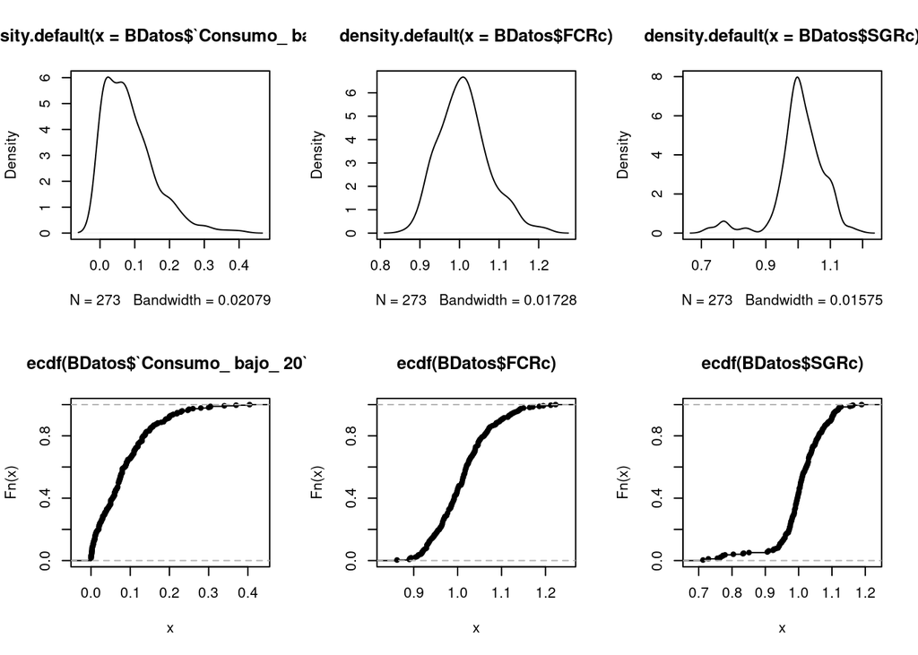

```r
par(mfrow=c(2,3))
plot (density(BDatos$`Consumo_ bajo_ 20`))
plot (density(BDatos$FCRc))
plot (density(BDatos$SGRc))
plot (ecdf(BDatos$`Consumo_ bajo_ 20`))
plot (ecdf(BDatos$FCRc))
plot (ecdf(BDatos$SGRc))
```

En la base de datos importada, los valores de las variables de estudio estaban en formato “número” y para una mejor comprensión estas variables deben expresarse en porcentajes. Por lo tanto, se realiza la transformación de estas a % y se seleccionan las variables de mayor interés para el estudio preliminar.

```r
BDatos_mod <- BDatos %>%
  mutate(Consumo_20=`Consumo_ bajo_ 20`*100, FCRc_porc=FCRc*100, SGRc_porc=SGRc*100) %>%
  dplyr::select(c(Year_class, Centro,Jaula, Consumo_20, FCRc_porc, SGRc_porc))
summary(BDatos_mod)
```

```
##  Year_class         Centro             Jaula       Consumo_20
##  2020: 51   Orestes    : 24   Chivato 1101:  1   Min.   : 0.000
##  2021:187   Elena Weste: 22   Chivato 1102:  1   1st Qu.: 2.613
##  2022: 35   Punta Cola : 22   Chivato 1103:  1   Median : 7.054
##             Punta Rouse: 22   Chivato 1104:  1   Mean   : 8.499
##             Williams 1 : 22   Chivato 1105:  1   3rd Qu.:12.117
##             Elena Norte: 21   Chivato 1106:  1   Max.   :40.443
##             (Other)    :140   (Other)     :267
##    FCRc_porc       SGRc_porc
##  Min.   : 86.2   Min.   : 71.3
##  1st Qu.: 96.8   1st Qu.: 97.8
##  Median :101.0   Median :100.7
##  Mean   :101.2   Mean   :100.7
##  3rd Qu.:104.7   3rd Qu.:105.0
##  Max.   :122.3   Max.   :118.9
##
```

```r
str(BDatos_mod)
```

```
## tibble [273 × 6] (S3: tbl_df/tbl/data.frame)
##  $ Year_class: Factor w/ 3 levels "2020","2021",..: 2 2 2 2 2 2 2 2 2 2 ...
##  $ Centro    : Factor w/ 16 levels "Chivato 1","Concheo 1",..: 1 1 1 1 1 1 1 1 1 1 ...
##  $ Jaula     : Factor w/ 273 levels "Chivato 1101",..: 18 17 14 10 2 8 9 7 1 15 ...
##  $ Consumo_20: num [1:273] 2.01 1.56 7.54 5.79 3.75 7.15 7.21 7.75 3.83 2.74 ...
##  $ FCRc_porc : num [1:273] 89.2 91 96.8 96.6 94.2 91.1 98.5 96.6 93.2 93.6 ...
##  $ SGRc_porc : num [1:273] 113 110 105 106 104 ...
```

Los gráficos de caja de las variables de estudio, indican la presencia de valores atípicos que deben ser investigados para su probable eliminación al momento de hacer el análisis estadístico.

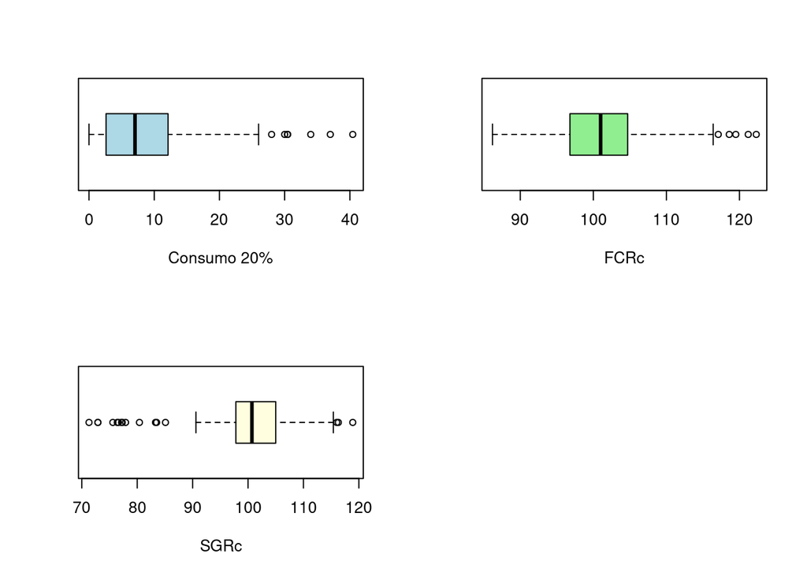

```r
par(mfrow=c(2,2))
boxplot(BDatos_mod$Consumo_20, horizontal=TRUE, col="light blue", xlab= "Consumo 20%")
boxplot(BDatos_mod$FCRc_porc, horizontal=TRUE, col="light green", xlab= "FCRc")
boxplot(BDatos_mod$SGRc_porc, horizontal=TRUE, col="light yellow", xlab= "SGRc")
```

```r
boxplot.stats(BDatos_mod$Consumo_20)
```

```
## $stats
## [1]  0.000000  2.612652  7.053713 12.116616 26.000000
##
## $n
## [1] 273
##
## $conf
## [1] 6.144888 7.962539
##
## $out
## [1] 30.00000 34.00000 30.41696 37.00000 28.00000 30.46684 40.44270
```

```r
boxplot.stats(BDatos_mod$FCRc_porc)
```

```
## $stats
## [1]  86.2  96.8 101.0 104.7 116.4
##
## $n
## [1] 273
##
## $conf
## [1] 100.2446 101.7554
##
## $out
## [1] 119.5 122.3 117.1 118.6 121.2
```

```r
boxplot.stats(BDatos_mod$SGRc_porc)
```

```
## $stats
## [1]  90.6  97.8 100.7 105.0 115.4
##
## $n
## [1] 273
##
## $conf
## [1] 100.0115 101.3885
##
## $out
##  [1] 118.9 116.0 116.3  76.6  76.4  77.2  75.6  72.9  72.9  71.3  77.2  80.4
## [13]  77.3  85.1  77.9  83.3  83.5
```

```r
Mi_gráfico = theme(axis.title.x = element_text(size = 12), axis.text.x = element_text(size = 12), axis.title.y = element_text(size = 12), axis.text.y = element_text(size = 12))
Mi_gráfico_2 = theme(axis.title.x = element_text(size = 16), axis.text.x = element_text(angle =45 , vjust= 1,0 , hjust= 1,0, size = 12), axis.title.y = element_text(size = 16), axis.text.y = element_text(size = 12))
```

Los histogramas construidos para las tres variables demuestran que habrían valores atípicos de manera más marcada en los datos de las variables de consumo bajo 20% de actividad y SGRc.

```r
Hist_Cons <- ggplot(BDatos_mod, aes(Consumo_20))+theme_gray()+
  geom_histogram(bins = 10, color= "black",fill="light blue")+
  labs(title="Hist. Consumo bajo 20% act.", x="Consumo bajo 20% actividad", y="Frecuencia")+ Mi_gráfico
```

```r
Hist_FCRc <- ggplot(BDatos_mod, aes(FCRc_porc))+theme_gray()+
  geom_histogram(bins = 10, color= "black",fill="light green")+
  labs(title="Histograma FCRc", x="FCRc (conversión)",y="Frecuencia")+ Mi_gráfico
```

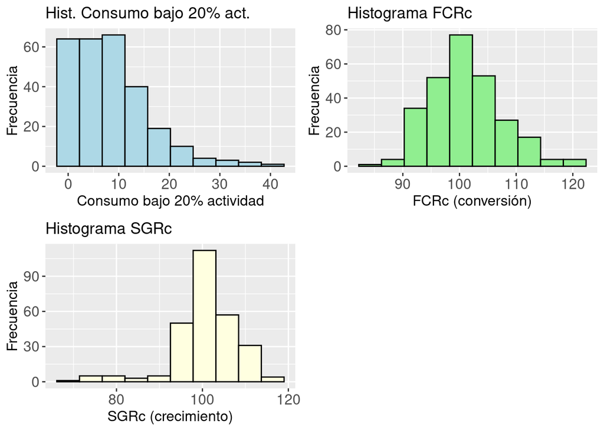

```r
Hist_SGRc <- ggplot(BDatos_mod, aes(SGRc_porc))+theme_gray()+
  geom_histogram(bins = 10, color= "black",fill="light yellow")+
  labs(title="Histograma SGRc", x="SGRc (crecimiento)",
       y="Frecuencia")+ Mi_gráfico
grid.arrange (Hist_Cons, Hist_FCRc, Hist_SGRc, ncol=2, nrow =2)
```

Los gráficos de caja a partir de Centro de cultivo para las variables FCRc y SGRc indican diversa variabilidad de los datos entre centros y valores atípicos que deben investigarse para su probable eliminación. Para una mejor visualización de los gráficos, lo nombres de los centros se reemplazan en algunos casos y en otros, se utiliza como nuevo identificador las tres primeras letras del nombre.

```r
BDatos_mod_2 <- BDatos_mod
BDatos_mod_2$Centro <- str_replace_all (BDatos_mod$Centro, c("Elena Norte" = "ElN", "Elena Weste"="ElW", "Punta Cola"= "PCo", "Punta Rouse"= "PRo", "Isla Level 2" = "Level"))
BDatos_mod_2 <- BDatos_mod_2 %>% mutate (ID_Centro= substr(Centro,1,3))
```

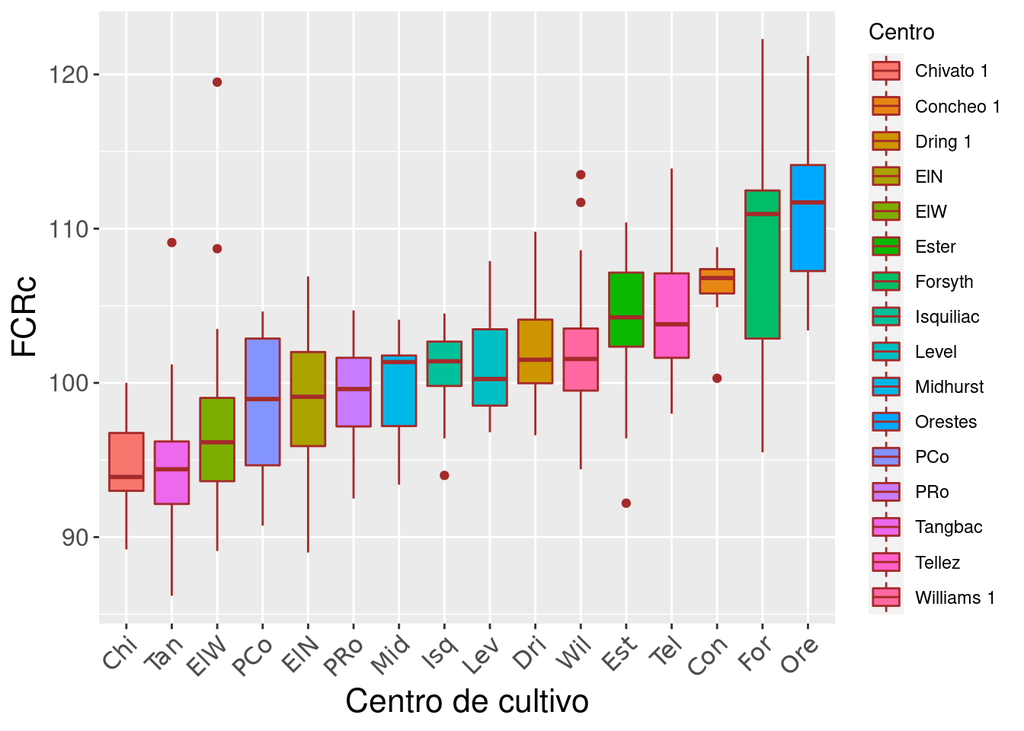

```r
ggplot(BDatos_mod_2 , aes(x=reorder(ID_Centro , FCRc_porc) , y=FCRc_porc , fill= Centro)) + geom_boxplot(color= "brown") + labs( x="Centro de cultivo", y="FCRc") + Mi_gráfico_2
```

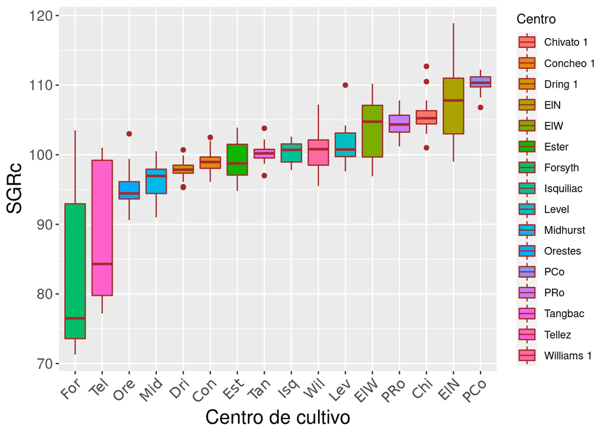

```r
ggplot(BDatos_mod_2 , aes(x= reorder(ID_Centro ,SGRc_porc), y=SGRc_porc ,fill=Centro)) +
    geom_boxplot(color= "brown") + labs( x="Centro de cultivo" , y="SGRc")+ Mi_gráfico_2
```

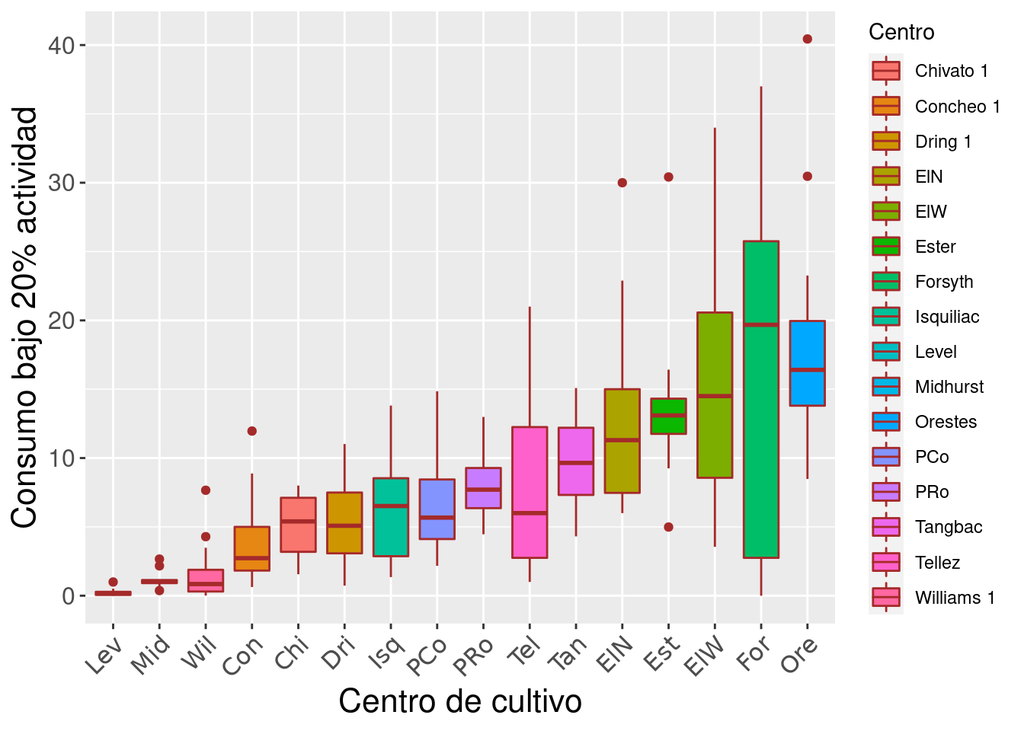

```r
ggplot(BDatos_mod_2 , aes(x= reorder(ID_Centro , Consumo_20), y= Consumo_20 ,fill=Centro)) +
    geom_boxplot(color= "brown") + labs( x="Centro de cultivo" , y="Consumo bajo 20% actividad")+ Mi_gráfico_2
```

En los gráficos de dispersión a partir de Consumo de alimento bajo 20% para FCRc y SFRc se puede observar la correlación entre las variables, con tendencia a aumentar el FCRc y disminuir el SGRc a medida que aumenta el consumo de alimento bajo 20% de actividad.

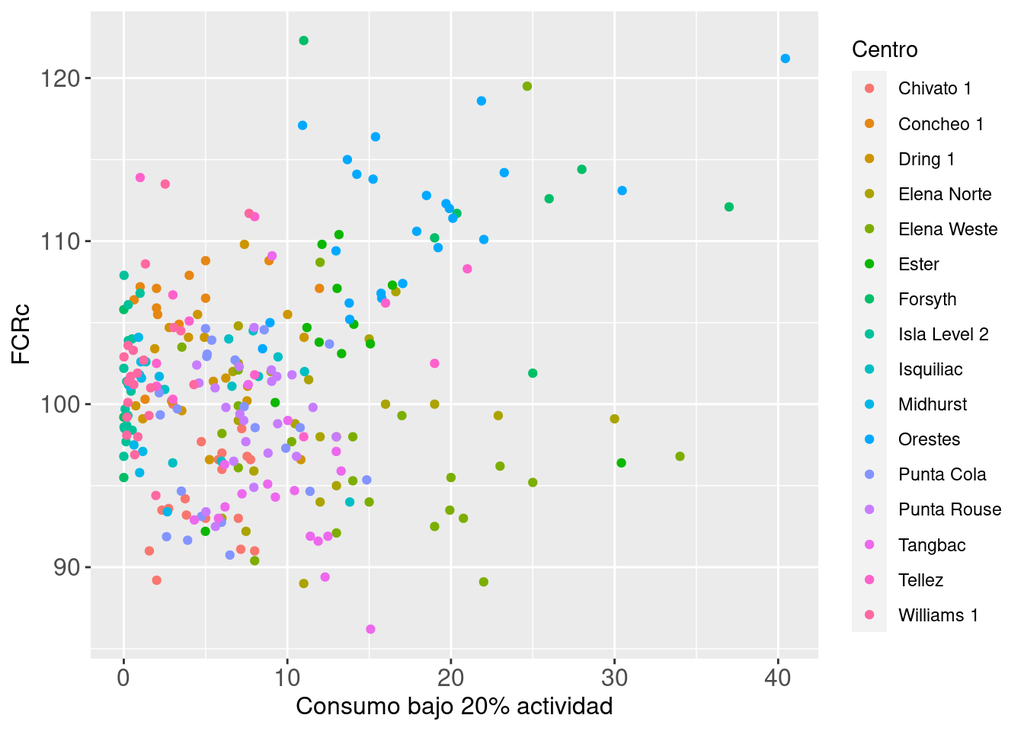

```r
ggplot(BDatos_mod , aes(x= Consumo_20 , y=FCRc_porc, color = Centro)) +
    geom_point() + labs( x="Consumo bajo 20% actividad" , y="FCRc")+ Mi_gráfico
```

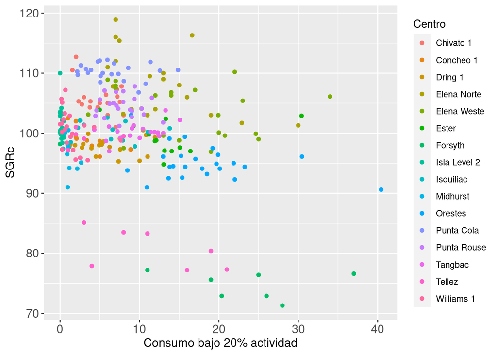

```r
ggplot(BDatos_mod , aes(x= Consumo_20 , y=SGRc_porc, color= Centro)) +
    geom_point () + labs( x="Consumo bajo 20% actividad" , y="SGRc")+ Mi_gráfico
```

Se construye una nueva tabla agrupando por Centro y considerando el promedio de cada variable de estudio.

```r
BDatos_mod %>% group_by(Centro) %>% summarise(Consumo20_prom = mean(Consumo_20), FCRc_prom = mean(FCRc_porc), SGRc_prom =mean(SGRc_porc))
```

```
## # A tibble: 16 × 4
##    Centro       Consumo20_prom FCRc_prom SGRc_prom
##    <fct>                 <dbl>     <dbl>     <dbl>
##  1 Chivato 1             5.08       94.6     106.
##  2 Concheo 1             3.94      106.       99.1
##  3 Dring 1               5.43      102.       97.8
##  4 Elena Norte          12.4        98.8     108.
##  5 Elena Weste          15.6        97.6     104.
##  6 Ester                13.7       104.       99.3
##  7 Forsyth              16.6       109.       82.5
##  8 Isla Level 2          0.242     101.      102.
##  9 Isquiliac             6.54      101.      100.
## 10 Midhurst              1.19       99.7      96.5
## 11 Orestes              17.9       111.       95.1
## 12 Punta Cola            6.62       98.4     110.
## 13 Punta Rouse           7.91       99.2     105.
## 14 Tangbac               9.68       94.9     100.
## 15 Tellez                8.17      105.       88.4
## 16 Williams 1            1.54      102.      101.
```

```r
BDatos_gcentro <- BDatos_mod %>% group_by(Centro) %>% summarise(Consumo20_prom = mean(Consumo_20), FCRc_prom = mean(FCRc_porc), SGRc_prom =mean(SGRc_porc))
BDatos_gcentro$Centro <- as.factor(BDatos_gcentro$Centro)
```

De la tabla anterior de filtran los % de consumo bajo el 20% de actividad mayores a 12%

```r
BDatos_gcentro %>% filter(Consumo20_prom > 12)%>%arrange(-Consumo20_prom)
```

```
## # A tibble: 5 × 4
##   Centro      Consumo20_prom FCRc_prom SGRc_prom
##   <fct>                <dbl>     <dbl>     <dbl>
## 1 Orestes               17.9     111.       95.1
## 2 Forsyth               16.6     109.       82.5
## 3 Elena Weste           15.6      97.6     104.
## 4 Ester                 13.7     104.       99.3
## 5 Elena Norte           12.4      98.8     108.
```

```r
BDatos_top <- BDatos_gcentro %>% filter(Consumo20_prom > 12)%>%arrange (-Consumo20_prom)
```

En el gráfico, la línea de tendencia indica que a mayor consumo de alimento bajo el 20% de actividad el FCRc aumentaría (considerando todos los datos).

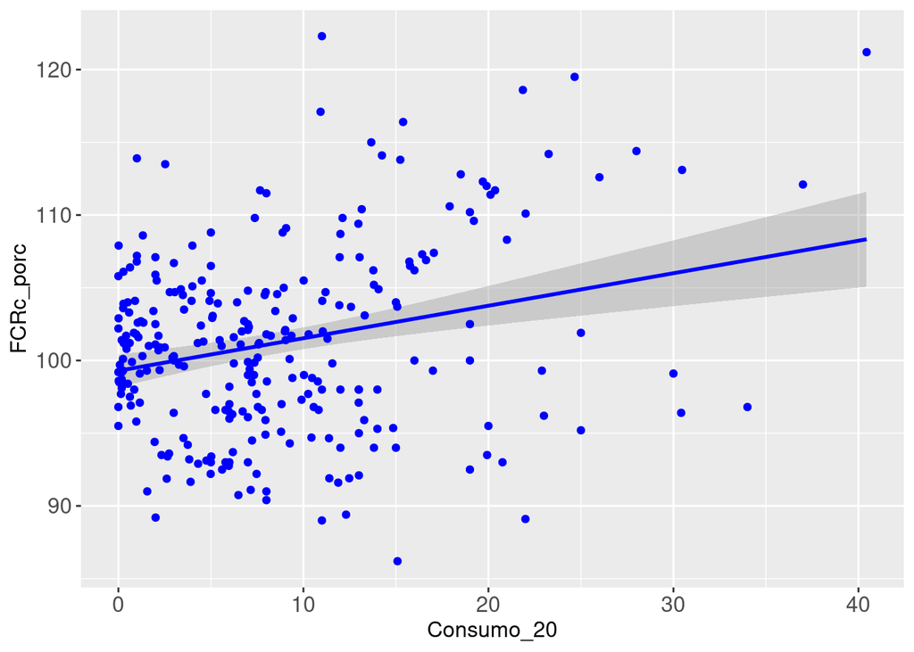

```r
 ggplot(BDatos_mod , aes(x= Consumo_20 , y=FCRc_porc))+ geom_smooth(method = "lm", formula = "y~x" , se= TRUE , color= "blue")+ geom_point(color= "blue") + Mi_gráfico
```

En el gráfico, la línea de tendencia indica que a mayor consumo de alimento bajo el 20% de actividad el SGRc disminuiría (considerando todos los datos).

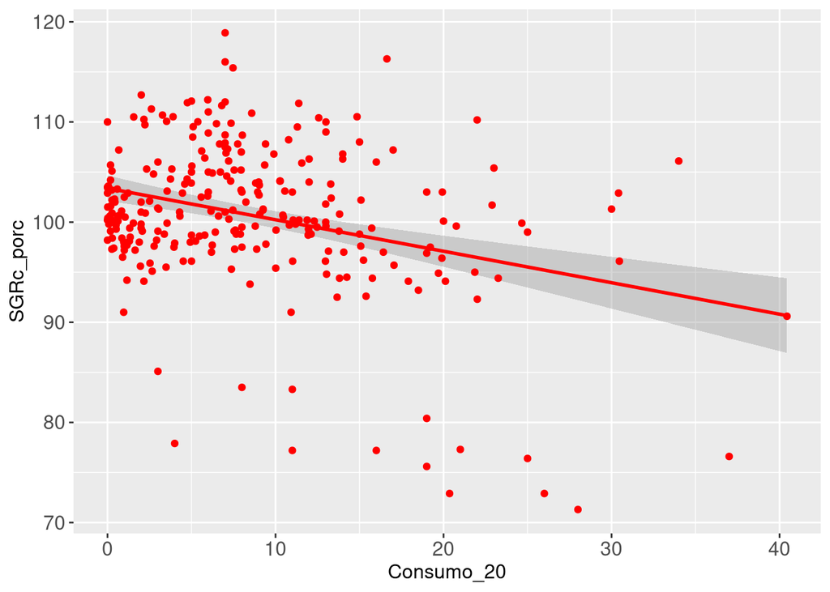

```r
 ggplot(BDatos_mod , aes(x= Consumo_20 , y=SGRc_porc)) + geom_smooth(method = "lm", formula= "y~x", se= TRUE, color= "red") + geom_point(color="red") + Mi_gráfico
```

## Correlación entre las variables

### -Prueba de correlación de Pearson

**H<sub>0</sub>:** : ρ = 0 ausencia de correlación.

**H<sub>1</sub>:** : ρ ̸= 0 existencia de correlación.

Se acepta la hipótesis alternativa. Existe correlación entre las variables, sin embargo el coeficiente de correlación en ambos casos es débil

```r
P_cor <-cor.test(x=BDatos_mod$Consumo_20 , y=BDatos_mod$FCRc_porc , method = "pearson", conf.level = 0.95)
pander::pander(P_cor, caption = "Prueba de hipótesis para el coeficiente de correlación entre Consumo bajo 20% y FCRc.")
```

Prueba de hipótesis para el coeficiente de correlación entre Consumo bajo 20% y FCRc.

| Test statistic | df | P value | Alternative hypothesis | cor |
| --- | --- | --- | --- | --- |
| 4.419 | 271 | 1.438e-05 * * * | two.sided | 0.2592 |

```r
P_cor <-cor.test(x=BDatos_mod$Consumo_20 , y=BDatos_mod$SGRc_porc , method = "pearson", conf.level = 0.95)
pander::pander(P_cor, caption = "Prueba de hipótesis para el coeficiente de correlación entre Consumo bajo 20% y SGRc.")
```

Prueba de hipótesis para el coeficiente de correlación entre Consumo bajo 20% y SGRc.

| Test statistic | df | P value | Alternative hypothesis | cor |
| --- | --- | --- | --- | --- |
| -5.439 | 271 | 1.196e-07 * * * | two.sided | -0.3137 |

```r
head(BDatos_top)
```

```
## # A tibble: 5 × 4
##   Centro      Consumo20_prom FCRc_prom SGRc_prom
##   <fct>                <dbl>     <dbl>     <dbl>
## 1 Orestes               17.9     111.       95.1
## 2 Forsyth               16.6     109.       82.5
## 3 Elena Weste           15.6      97.6     104.
## 4 Ester                 13.7     104.       99.3
## 5 Elena Norte           12.4      98.8     108.
```

Cuando se considera la selección de los centros con los consumos más altos bajo 20% de de actividad y su relación con las variables FCRc y SGRc la correlación aumenta de manera considerable en ambos casos. La correlación entre consumo bajo 20% y FCRc es positiva, es decir, el aumento de una variable significa un aumento de la otra, a diferencia de la correlación negativa que demuestra la variable SGRC.

```r
P_cor <-cor.test(x=BDatos_top$Consumo20_prom , y=BDatos_top$FCRc_prom , method = "pearson", conf.level = 0.95)
pander::pander(P_cor, caption = "Prueba de hipótesis para r entre centros con mayores consumo bajo 20% de actividad y FCRc.")
```

Prueba de hipótesis para r entre centros con mayores consumo bajo 20% de actividad y FCRc.

| Test statistic | df | P value | Alternative hypothesis | cor |
| --- | --- | --- | --- | --- |
| 1.923 | 3 | 0.1501 | two.sided | 0.7431 |

```r
P_cor <-cor.test(x=BDatos_top$Consumo20_prom , y=BDatos_top$SGRc_prom , method = "pearson", conf.level = 0.95)
pander::pander(P_cor, caption = "Prueba de hipótesis para r entre centros con mayores consumo bajo 20% de actividad y SGRc.")
```

Prueba de hipótesis para r entre centros con mayores consumo bajo 20% de actividad y SGRc.

| Test statistic | df | P value | Alternative hypothesis | cor |
| --- | --- | --- | --- | --- |
| -1.546 | 3 | 0.2198 | two.sided | -0.6659 |

## Planteamiento de hipótesis y definición del modelo

Para comprobar si el consumo de alimento bajo la fase de actividad del 20% afecta el rendimiento productivo, en este caso se eligió contrastar a través de análisis estadístico, el consumo en esta fase con la variable de conversión de alimento, ya que por su naturaleza es la variable respuesta que se relaciona de mejor manera con la variable consumo. De este modo, las hipótesis nula y alternativa a contrastar serían:

**H<sub>0</sub>:** El consumo de alimento bajo 20% de actividad *no afecta el FCR.*

**H<sub>1</sub>:** El consumo de alimento bajo 20% de actividad *afecta el FCR.*

Se plantea un modelo que define al FCRc como variable respuesta en función de las variables consumo bajo 20% de actividad, centro de cultivo y año de cultivo.

```r
Lineal <- lm(FCRc_porc ~ Consumo_20 + Centro + Year_class, data = BDatos_mod)
```

## Evaluación de los supuestos del modelo

### -Evaluación gráfica de supuestos

La evaluación gráfica indicaría que se estarían cumpliendo los supuestos de independencia, homogeneidad de varianzas y normalidad.

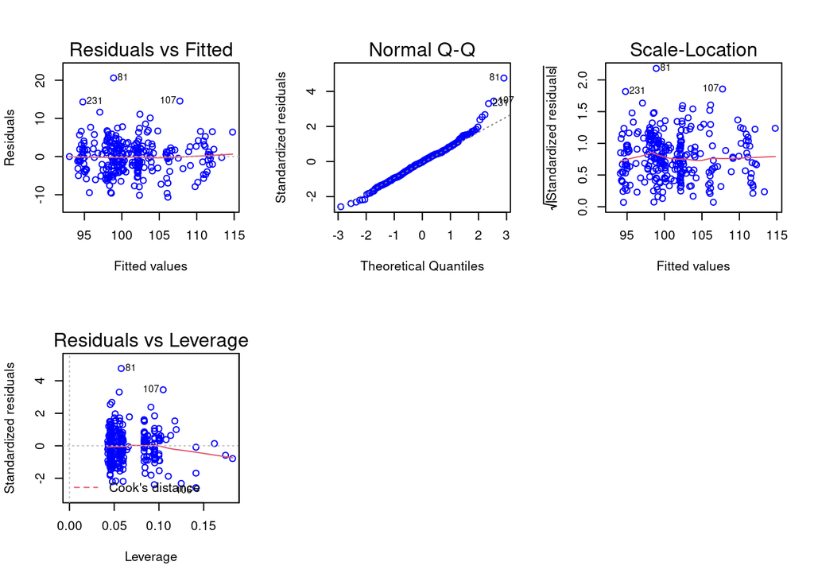

```r
par(mfrow=c(2,3))
plot(Lineal, col="blue")
```

## Evaluación estadística de supuestos

### -Independencia de las muestras

Se establecen las hipótesis nula y alternativa para correlación.

**H<sub>0</sub>:** No existe autocorrelación entre los residuales

**H<sub>1</sub>:** Existe autocorrelación entre los residuales

De acuerdo a la Prueba de Durbin-Watson efectuada el p-value > 0,05 , por lo tanto se acepta H0 y no existe autocorrelación entre los residuales.

```r
dwtest(FCRc_porc ~ Consumo_20 + Centro + Year_class, data = BDatos_mod, alternative = c("two.sided"), iterations = 15)
```

```
##
##  Durbin-Watson test
##
## data:  FCRc_porc ~ Consumo_20 + Centro + Year_class
## DW = 2.1057, p-value = 0.9336
## alternative hypothesis: true autocorrelation is not 0
```

### -Homogeneidad de las varianzas

**H<sub>0</sub>:** Las varianzas de los residuos son iguales

**H<sub>1</sub>:** Las varianzas de los residuos no son iguales

De acuerdo a la prueba de Breusch-Pagan aplicada, el p- value > 0,05, por lo tanto se acepta H0.

```r
bptest(FCRc_porc ~ Consumo_20 + Centro + Year_class, data = BDatos_mod)
```

```
##
##  studentized Breusch-Pagan test
##
## data:  FCRc_porc ~ Consumo_20 + Centro + Year_class
## BP = 24.61, df = 18, p-value = 0.136
```

### -Normalidad

**H<sub>0</sub>:** La distribución de la variable es normal

**H<sub>1</sub>:** La distribución de la variable no es normal

De acuerdo a la prueba de Shapiro-Wilk aplicada el p-value < 0,05, por lo tanto se rechaza H0 y se concluye que la distribución de los datos no es normal.

```r
shapiro.test (residuals(Lineal))
```

```
##
##  Shapiro-Wilk normality test
##
## data:  residuals(Lineal)
## W = 0.97393, p-value = 6.906e-05
```

## Eliminación de valores atípicos

Se eliminan los valores atípicos detectados en la gráfica de residuales estandarizados con valores de distancia de Cook mayores a 2 y -2. Estas serían las observaciones 81, 106 y 107 de la base de datos “BDatos-mod”. Se crea una nueva base con estas observaciones excluidas “BDatos_mod_f”.

```
##
##  Shapiro-Wilk normality test
##
## data:  residuals(Lineal2)
## W = 0.99365, p-value = 0.3122
```

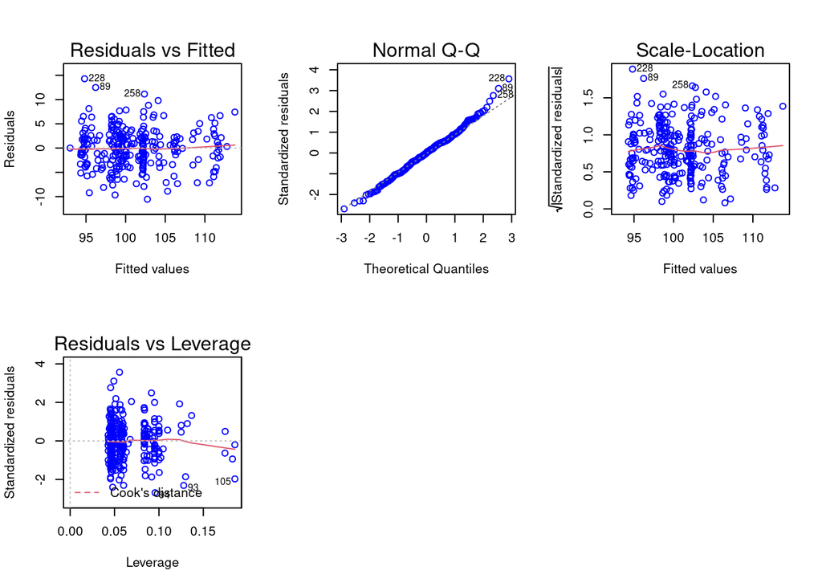

```r
BDatos_mod_f <- BDatos_mod[-c(81, 106,107),]
Lineal2 <- lm(FCRc_porc ~ Consumo_20 + Centro + Year_class, data = BDatos_mod_f)
par(mfrow=c(2,3))
plot(Lineal2, col= "blue")
shapiro.test(residuals(Lineal2))
```

Al aplicar de nuevo los test de evaluación de supuestos sobre el modelo con estos datos corregidos, se cumplen ahora todos los supuestos evaluados.

```r
dwtest(FCRc_porc ~ Consumo_20 + Centro + Year_class, data = BDatos_mod_f, alternative = c("two.sided"), iterations = 15)
```

```
##
##  Durbin-Watson test
##
## data:  FCRc_porc ~ Consumo_20 + Centro + Year_class
## DW = 2.0753, p-value = 0.7315
## alternative hypothesis: true autocorrelation is not 0
```

```r
bptest(FCRc_porc ~ Consumo_20 + Centro + Year_class, data = BDatos_mod_f)
```

```
##
##  studentized Breusch-Pagan test
##
## data:  FCRc_porc ~ Consumo_20 + Centro + Year_class
## BP = 16.796, df = 18, p-value = 0.5372
```

```r
shapiro.test(residuals(Lineal2))
```

```
##
##  Shapiro-Wilk normality test
##
## data:  residuals(Lineal2)
## W = 0.99365, p-value = 0.3122
```

Se realiza un análisis de varianza al nuevo modelo. Los valores de F encontrados indican que tanto las variables consumo bajo 20% de actividad como Centro afectan a la variable respuesta. Asimismo, esto no ocurre con la variable Year class.

```r
anova <- anova(Lineal2)
pander::pander(anova, caption = "ANOVA de tres factores sobre la variable FCRc.")
```

ANOVA de tres factores sobre la variable FCRc.

|  | Df | Sum Sq | Mean Sq | F value | Pr(>F) |
| --- | --- | --- | --- | --- | --- |
| **Consumo_20** | 1 | 588.2 | 588.2 | 34.6 | 1.289e-08 |
| **Centro** | 15 | 5339 | 356 | 20.93 | 3.86e-36 |
| **Year_class** | 2 | 31.1 | 15.55 | 0.9146 | 0.402 |
| **Residuals** | 251 | 4268 | 17 | NA | NA |

En la tabla resumen se observa un p-value < 0,05, lo que indica que el modelo tiene capacidad predictiva y el valor de R2 ajustado indica que el modelo tiene una proporción de predicción de 55%, debido a la alta variabilidad de la variable respuesta.

```r
tab_model(Lineal2, show.se = TRUE, show.aic=TRUE)
```

|  | FCRc_porc |  |  |  |
| --- | --- | --- | --- | --- |
| Predictors | Estimates | std. Error | CI | p |
| (Intercept) | 92.01 | 1.93 | 88.21 – 95.81 | **<0.001** |
| Consumo 20 | 0.10 | 0.05 | -0.00 – 0.20 | 0.056 |
| Centro [Concheo 1] | 13.47 | 4.29 | 5.02 – 21.93 | **0.002** |
| Centro [Dring 1] | 7.40 | 1.39 | 4.65 – 10.15 | **<0.001** |
| Centro [Elena Norte] | 3.43 | 1.40 | 0.67 – 6.18 | **0.015** |
| Centro [Elena Weste] | 0.88 | 1.44 | -1.97 – 3.72 | 0.545 |
| Centro [Ester] | 8.11 | 1.62 | 4.92 – 11.30 | **<0.001** |
| Centro [Forsyth] | 14.04 | 4.44 | 5.30 – 22.78 | **0.002** |
| Centro [Isla Level 2] | 8.04 | 1.63 | 4.83 – 11.25 | **<0.001** |
| Centro [Isquiliac] | 5.83 | 1.56 | 2.77 – 8.90 | **<0.001** |
| Centro [Midhurst] | 5.41 | 1.66 | 2.15 – 8.67 | **0.001** |
| Centro [Orestes] | 15.59 | 1.48 | 12.68 – 18.50 | **<0.001** |
| Centro [Punta Cola] | 3.58 | 1.33 | 0.95 – 6.21 | **0.008** |
| Centro [Punta Rouse] | 6.39 | 2.13 | 2.21 – 10.58 | **0.003** |
| Centro [Tangbac] | 1.90 | 2.18 | -2.39 – 6.19 | 0.385 |
| Centro [Tellez] | 11.51 | 4.30 | 3.05 – 19.97 | **0.008** |
| Centro [Williams 1] | 7.98 | 1.34 | 5.33 – 10.62 | **<0.001** |
| Year class [2021] | 2.13 | 1.64 | -1.11 – 5.36 | 0.196 |
| Year class [2022] | 0.49 | 4.55 | -8.47 – 9.45 | 0.915 |
| Observations | 270 |  |  |  |
| R<sup>2</sup> / R<sup>2</sup> adjusted | 0.583 / 0.553 |  |  |  |
| AIC | 1551.540 |  |  |  |

```r
summary(Lineal2)
```

```
##
## Call:
## lm(formula = FCRc_porc ~ Consumo_20 + Centro + Year_class, data = BDatos_mod_f)
##
## Residuals:
##      Min       1Q   Median       3Q      Max
## -10.5468  -2.5637   0.0133   2.3150  14.2841
##
## Coefficients:
##                    Estimate Std. Error t value Pr(>|t|)
## (Intercept)        92.01020    1.92711  47.745  < 2e-16 ***
## Consumo_20          0.10025    0.05223   1.919 0.056065 .
## CentroConcheo 1    13.47343    4.29220   3.139 0.001898 **
## CentroDring 1       7.40163    1.39467   5.307 2.45e-07 ***
## CentroElena Norte   3.42900    1.39852   2.452 0.014894 *
## CentroElena Weste   0.87538    1.44382   0.606 0.544868
## CentroEster         8.10933    1.61922   5.008 1.04e-06 ***
## CentroForsyth      14.04196    4.43796   3.164 0.001748 **
## CentroIsla Level 2  8.04075    1.63034   4.932 1.48e-06 ***
## CentroIsquiliac     5.83148    1.55657   3.746 0.000223 ***
## CentroMidhurst      5.41274    1.65581   3.269 0.001231 **
## CentroOrestes      15.58795    1.47832  10.544  < 2e-16 ***
## CentroPunta Cola    3.57846    1.33398   2.683 0.007792 **
## CentroPunta Rouse   6.39191    2.12530   3.008 0.002901 **
## CentroTangbac       1.89688    2.17765   0.871 0.384549
## CentroTellez       11.50756    4.29503   2.679 0.007866 **
## CentroWilliams 1    7.97645    1.34436   5.933 9.81e-09 ***
## Year_class2021      2.12737    1.64128   1.296 0.196107
## Year_class2022      0.48857    4.54930   0.107 0.914562
## ---
## Signif. codes:  0 '***' 0.001 '**' 0.01 '*' 0.05 '.' 0.1 ' ' 1
##
## Residual standard error: 4.123 on 251 degrees of freedom
## Multiple R-squared:  0.5827, Adjusted R-squared:  0.5527
## F-statistic: 19.47 on 18 and 251 DF,  p-value: < 2.2e-16
```